# Introduction to RMarkdown

[*R-Ladies East Lansing*](https://rladies-eastlansing.github.io)

2020-02-24

```r
library(tidyverse)
library(ggplot2)
library(skimr)
library(knitr)
library(kableExtra)
library(ggpubr)
library(janitor)
```

## RMarkdown workshop description

During this workshop, we will cover the basics of RMarkdown. You have already heard about the power of RMarkdown for weaving together code and narrative to conduct science in a transparent and reproducible manner, and communicate results in a neatly compiled document or presentation. You have also been introduced to its anatomy and structure, and seen what a basic RMarkdown file looks like.

Now, it’s time to get our hands dirty by making an RMarkdown file together as a group! In this tutorial, you will learn different ways to manipulate text, figures, and tables to produce aesthetically pleasing and cohesive reports. Since most of us have created or used plain old R files but not necessarily Rmd files, we will go through the process of creating an Rmd file using existing code from other R files. Specifically, we will take the code from part2.R file from our last workshop and create an Rmd file with it! In the end, you will each have created a file that weaves together the R code from part2 with narrative that explains how different bits of code work and what the output tells us.

## RMarkdown workshop learning objectives

The goals for today’s workshop are to:

- Create an RMarkdown document
- Learn a to manipulate
  - text
  - figures
  - tables

## RMarkdown overview

There are three basic components of an RMarkdown document: the metadata, text, and code. The metadata is written between the pair of three dashes —. The syntax for the metadata is YAML (YAML Ain’t Markup Language, https://en.wikipedia.org/wiki/YAML), so sometimes it is also called the YAML metadata or the YAML front matter. The body of a document comes after the metadata. The syntax for text is Markdown. There are two types of computer code, inline code and code chunks ([*R Markdown: The Definitive Guide*](https://bookdown.org/yihui/rmarkdown/))

## Text manipulation in RMarkdown

### Headers

You can create headers of various sizes by adding one or more `#` before a word or phrase:

# Header 1

## Header 2

### Header 3

#### Header 4

##### Header 5

### Hyperlinks

Hyperlinks can be inserted in the body of your text a couple of ways. To display the website address as a hyperlink, simply write the web address inside brackets, e.g. `<web address>`, like so:

For more RMarkdown fun, try this interactive RMarkdown tutorial: https://commonmark.org/help/tutorial.

Alternatively, you can create a hyperlink that displays as a word or phrase using the syntax `[text to be displayed](website address)`. For example:

You can also check out these [cheatsheets](https://rstudio.com/resources/cheatsheets/) created by RStudio, including one for RMarkdown.

### Indented lists

To create a list, simply add a `-` or `*` before a phrase. For example,

- List item 1
- List item 2
- List item 3

### Footnotes

To create a footnote, write text inside square brackets, placed after a caret `^[]`. It will be displayed at the bottom of the rendered Rmd document. For example, [^1]

### Code chunks

To insert a new chunk, type `Cmd + Option + I` (Mac) OR `Ctrl + Alt + I` (Win).

Below is an example code chunk from [*R Markdown: The Definitive Guide*](https://bookdown.org/yihui/rmarkdown/)

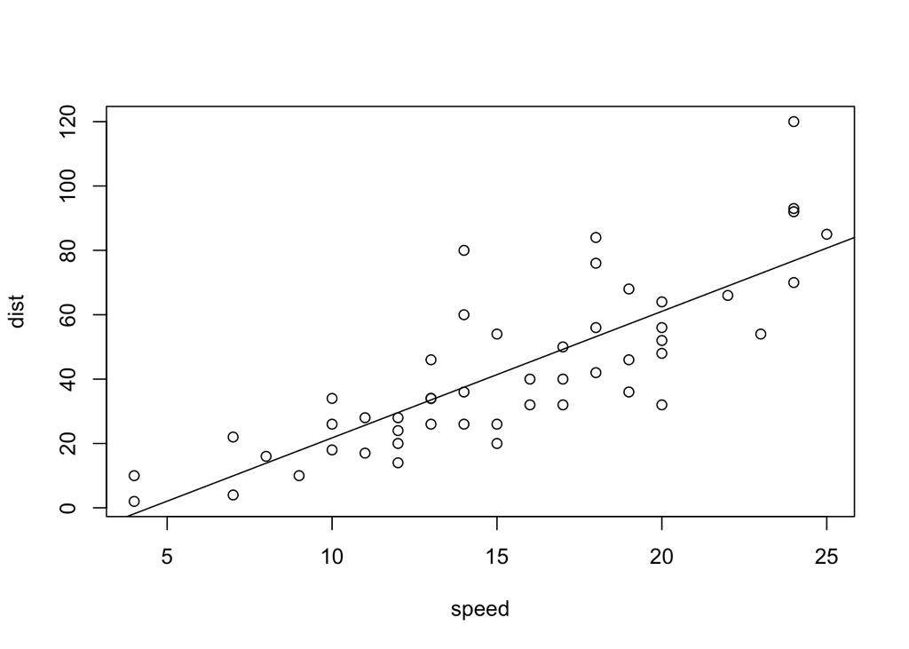

```r
fit = lm(dist ~ speed, data = cars)
b   = coef(fit)
plot(cars)
abline(fit)
```

### Inline code

To include code in the body of your text, type the letter r then your code, surrounded by backticks. For example, 8

The slope of the regression is 3.9324088.

## Figure manipulation RMarkdown

### Inserting a figure in RMarkdown

#### Option 1: using code within a chunk to CREATE and display the figure.

As we just saw in the previous example, the output of some codes can create figures that will automatically get inserted into RMarkdown.

So, now, let’s try to do a more fancy plot using ggplot2. Whether you have loaded ggplot2 globally or not, I recommend loading the ggplot2 library as part of the new chunk. It won’t hurt and would rather help to avoid errors during knitting.

Please go ahead and paste the lines 35 to 38 from the file Part2.R as part of the following chucks (in line 85)

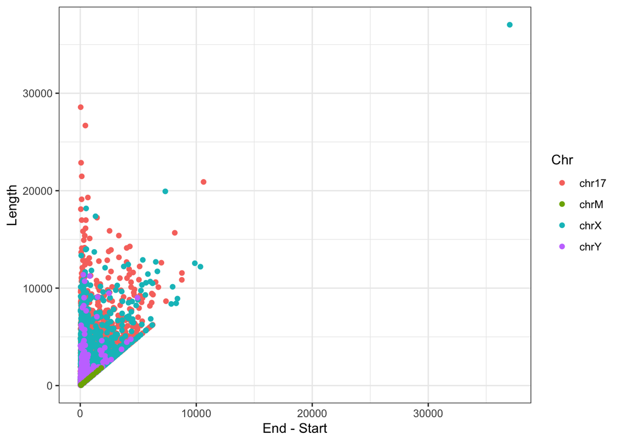

````r
##```{r, message=F}
##```{r, message=F, echo=F}
##```{r, message=F, echo=F, fig.show="hide"}print("You will not see the figure")

## Data Import
gene_loc <- read.table("gene_loc2.txt",
                       header = T)
### Insert lines 35 to 38 from file Part2.R in here ##
scatter <- ggplot(gene_loc, aes(x = End-Start, y = Length, group=Chr, color=Chr)) +
  geom_point() +
  theme_bw()
scatter
````

Consider to hide the code, the text output, the messages, or even the plots changing the global settings of the plot. Try this options!

- {r, echo=FALSE}
- {r, results=‘hide’}
- {r, message=FALSE}
- {r, fig.show=‘hide’}

#### Option 2: using code within a chunk to IMPORT and display the figure.

```r
knitr::include_graphics("./rladies_figure.png")
```

[output not shown]

### Setting figure size in RMarkdown

There are a couple ways to adjust figure size in RMarkdown. It can be done globally, in which case all the figures/plots in our file would have the same size, or it can be done chunk by chunk.

##### Chunk options to adjust size:

From code within a chunk to create and display the figure.

- {r, fig.height = 2, fig.width = 4}. Specified height and width. Note that the numbers default to inches as unit:
- {r, fig.height = 2, fig.width = 4, fig.align = “center”}. Define the position of the plot.
- {r fig.width = 4, fig.asp = 0.5}. Change the aspect ratio of the image as a function of one parameter.
- {r, out.width = "90%}. Change the aspect ratio of the image as a whole.

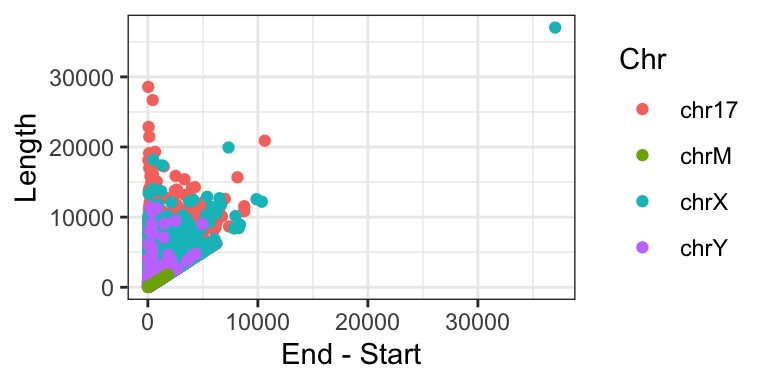

From code within a chunk to create and display the figure.

- {r, out.width = “70%”}

## Table manipulation in RMarkdown

Source: **Rmd for Medicine**[^2]

### Custom Typed tables

| Time | Session | Topic |
| --- | --- | --- |
| *left* | *center* | *right* |
| 06:00 - 6:10 | 1 | Intro |
| 06:10 - 6:30 | 2 | Metadata |
| 06:30 - 6:45 | 3 | Text |
| 06:45 - 7:10 | 4 | Code |
| 07:10 - 7:30 | 5 | Tables |

> Add a final row to the table above that indicates `networking` occurs from `7:30 - 8:00`

> Edit the yaml to indicate `toc:true`, `toc_float: true` and `toc_depth: 2`

### View Data

Maybe you want to share a view of the raw data with our research group!

> Set the `df_print` option in the yaml to `paged` to print html tables which support pagination.

```r
#gene_loc
```

> specify `rows.print` and `cols.print` to indicate number of rows and columns resp. to display

### Exploratory Data Analysis (EDA) Tables

#### Overview

Several packages support making beautiful tables w/R [^2].  
* `xtable` * `stargazer` * `pander` * `ascii`

Suppose we have some data that is displayed as a dataframe or matrix in the R terminal. We can include additional formating to make publication ready tables by using the `knitr::kable` and `kableExtra`. Note: **This function does not replace any of the other R packages for making tables.**

For example, if you perfer to show a summary table to describe your data.

```r
# Example to show you can use all math/stat functions to summarize data
gene_loc %>%
  skimr::skim() %>%
  yank("numeric") %>%
  knitr::kable() %>%
  kable_styling()
```

| skim_variable | n_missing | complete_rate | mean | sd | p0 | p25 | p50 | p75 | p100 | hist |
| --- | --- | --- | --- | --- | --- | --- | --- | --- | --- | --- |
| Start | 0 | 1 | 54653827.691 | 41584557.325 | 577 | 21760289.00 | 45262502.0 | 75082798 | 155255323 | ▇▆▃▂▂ |
| End | 0 | 1 | 54654504.242 | 41584573.512 | 647 | 21760787.00 | 45262863.0 | 75082945 | 155256502 | ▇▆▃▂▂ |
| Length | 0 | 1 | 2046.549 | 2679.543 | 28 | 353.25 | 948.5 | 2758 | 37027 | ▇▁▁▁▁ |

**Note:** results, when set to ‘hide’, text output will be hidden; when set to `asis`, text output is written “as-is”.

```r
stable %>%
  kable(align = "c", caption = "Table 1: Descriptive statistics for gene loc data") %>%
  kable_styling(full_width = F) %>%
  footnote(general = "Here are the general comments for this table.",
           general_title = "My first Table",
           symbol = c("pay attention to this", "check this out")
           )
```

Table 1: Descriptive statistics for gene loc data

| Chr | length | mean | sd |
| --- | --- | --- | --- |
| chr17 | 2903 | 2429.7392 | 2968.3772 |
| chrM | 37 | 416.6486 | 525.8688 |
| chrX | 2392 | 1800.3361 | 2441.5129 |
| chrY | 542 | 1192.0166 | 1531.8872 |

My first Table  
Here are the general comments for this table.  
* pay attention to this  
† check this out

> `skim()` is really nice for summarizing data because it accepts and outputs a number of data types. In your console, type `class(skimr::skim(gene_loc))` to see the output types available. `class(ggpubr::desc_statby(gene_loc))` on the other hand outputs a data.frame object.

```r
# Combine by a variable, then calculate summary statistics for each group
gene_loc %>%
  group_by(Chr) %>%                             # combine rows by Chr
  summarize(numGenes = n(),                     # then summarise, number of genes/Chr
            startoffirstGene = min(Start)) %>%      # min to get the first Start location
  knitr::kable() %>%
   kable_styling()
```

| Chr | numGenes | startoffirstGene |
| --- | --- | --- |
| chr17 | 2903 | 4961 |
| chrM | 37 | 577 |
| chrX | 2392 | 170410 |
| chrY | 542 | 120410 |

> use `paged.print =FALSE` to turn off paged tables.

##### 1- and 2-way frequency tables with categorical variables

Suppose we want to count tne number of genes by `Chr`

```r
gene_loc %>%
  tabyl(Chr) %>%
  adorn_totals("row") %>%
  adorn_pct_formatting() %>%
  knitr::kable() %>%
   kable_styling()
```

| Chr | n | percent |
| --- | --- | --- |
| chr17 | 2903 | 49.4% |
| chrM | 37 | 0.6% |
| chrX | 2392 | 40.7% |
| chrY | 542 | 9.2% |
| Total | 5874 | 100.0% |

> Modify the code above to create a 2-way frequency table of counts of `Chr` by `Strand`. Compute percentages by row with `adorn_percentages("row")` and add counts with `adorn_ns()`. Limit the # of decimal places by modifying `adorn_pct_formating()`.

#### Model Fitting

```r
data(mtcars)
m.mtcars <- lm(mpg ~ cyl + hp + wt, data = mtcars)
summary(m.mtcars)
```

```
##
## Call:
## lm(formula = mpg ~ cyl + hp + wt, data = mtcars)
##
## Residuals:
##     Min      1Q  Median      3Q     Max
## -3.9290 -1.5598 -0.5311  1.1850  5.8986
##
## Coefficients:
##             Estimate Std. Error t value Pr(>|t|)
## (Intercept) 38.75179    1.78686  21.687  < 2e-16 ***
## cyl         -0.94162    0.55092  -1.709 0.098480 .
## hp          -0.01804    0.01188  -1.519 0.140015
## wt          -3.16697    0.74058  -4.276 0.000199 ***
## ---
## Signif. codes:  0 '***' 0.001 '**' 0.01 '*' 0.05 '.' 0.1 ' ' 1
##
## Residual standard error: 2.512 on 28 degrees of freedom
## Multiple R-squared:  0.8431, Adjusted R-squared:  0.8263
## F-statistic: 50.17 on 3 and 28 DF,  p-value: 2.184e-11
```

> How do we make the html or pdf output pretty?

### References/Footnotes

[^1]: I am a footnote.
[^2]: https://rmd4medicine.netlify.com/materials/